# Charlotte, New Orleans and the Ghost of the Hornets

Bad draft decisions and plain bad luck have haunted N.C.’s basketball franchise.

*Rendered at 10:54 AM, Jun. 02, 2023*

*Lucas Thomae (ljthomae@email.unc.edu)*

Earlier in May, the Charlotte Hornets did something that this iteration of the franchise has only done one other time: win the second pick in the NBA Draft.

And while the second overall pick is by no means a disappointing lottery placement, its hard not to draw comparisons to the last time Charlotte found itself in this position back in 2012. Then, 19-year-old Anthony Davis, a seven-footer out of Kentucky, was considered the undisputed first pick. The Hornets just missed out on the generational talent and instead took Michael Kidd-Gilchrist at No. 2, who was largely seen as a bust.

This time around, there’s another agreed-upon No. 1 talent – Victor Wembanyama. The seven-foot-two Frenchman has NBA executives drooling, while Alabama one-and-done Brandon Miller and Scoot Henderson of the G-League Ignite are in a battle for second place. The Hornets, trapped in a positive feedback loop of mediocrity, are in desperate need of star talent and will have to hope they don’t swing and miss in the draft once again.

But where did it all go wrong? The Hornets of the decades past were fun. They had 5-foot-3 phenom Muggsy Bogues and powerful forward Larry Johnson, and they were regulars in the playoffs despite never quite being able to overcome the Jordan Bulls and Ewing Knicks.

Well, that Hornets franchise up and left for New Orleans in 2002. It’d be more accurate to link the winning history of the 1990s Hornets to the current New Orleans Pelicans than it would be to attribute it to the Charlotte Hornets of today.

The contemporary Hornets are more like ghastly apparition, taking the form of the old Charlotte franchise but not sharing in any of its history or winning tradition. In 2004, the NBA granted Charlotte another expansion franchise and the Bobcats were born. The only problem was that they sucked. Like, really bad.

Ahead of the 2014-15 season, New Orleans became the Pelicans while Charlotte took back its Hornets branding. But the name change didn’t do much at all to bring back the team’s winning ways. Let’s take a look at how the team has fared since the 2004 expansion.

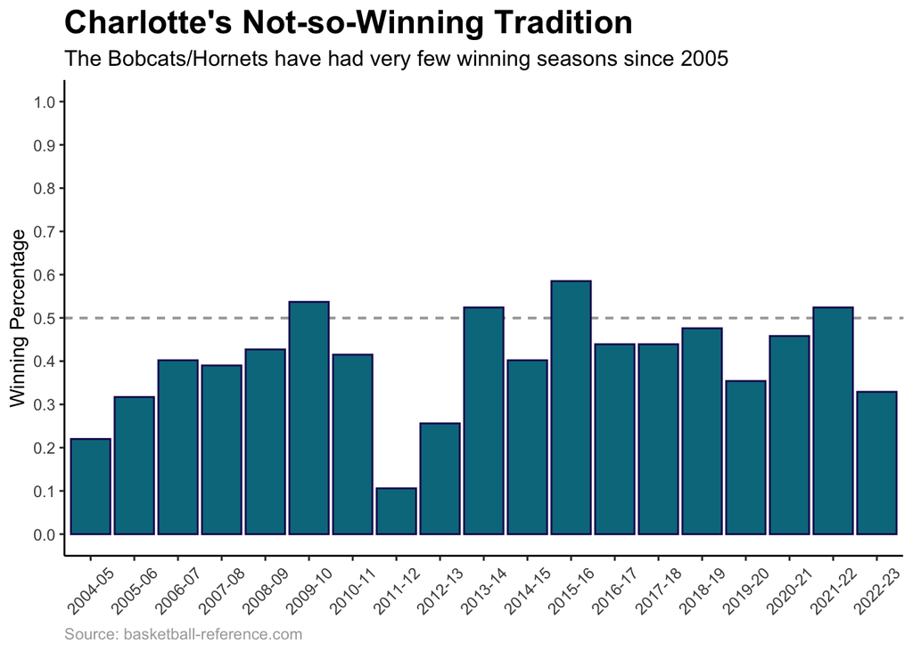

Woof. The Bobcats and Hornets 2.0 have had a total of four winning seasons and have made the playoffs thrice in 19 years. But naturally, that would mean the team has had plenty of chances in the draft to turn its prospects around? Not quite.

Each year, the 14 NBA teams that don’t make the playoffs participate in a lottery system to decide placement in that year’s draft. Many years, the Hornets have hovered close enough to .500 to not be in serious contention for a very high pick.

Often, the cycle goes like this: The Hornets win between 30-40 games, they earn a pick somewhere in the 8-13 range, select a role player at best, and the next season they win another 30-40 games. A cycle of mediocrity.

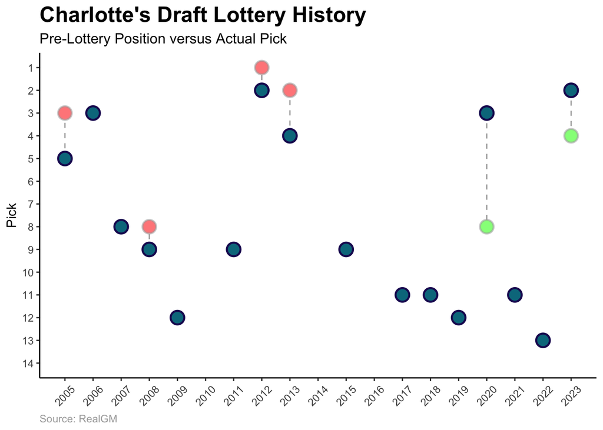

Charlotte has bucked the trend a few times and landed a high pick, but even many of those instances are intertwined with disappointment. Take a look at the 2005 draft. The Bobcats were projected to have the No. 3 pick but they fell to No. 5 in the lottery and selected North Carolina point guard Raymond Felton.

Felton was certainly not a bad pick – he played 15 seasons in the league and was a serviceable floor general. But none other than Chris Paul was taken one spot ahead of Felton, and, ironically, it was the New Orleans Hornets who landed the future Hall of Famer.

We can compare the individual impact of a basketball player on his/her team using a metric called Wins Over Replacement (WORP). This metric takes into account box score plus/minus (BPM) and % of possessions played to estimate how many wins a player contributed to a team when compared to a replacement-level player.

In his six seasons in New Orleans, Chris Paul contributed around extra 104 wins. Essentially, his WORP numbers say that when compared to a replacement-level player, the Hornets could expect to win an extra ~17.4 games because of Paul. Felton on the hand was just above average. He didn’t move the needle too much in either direction.

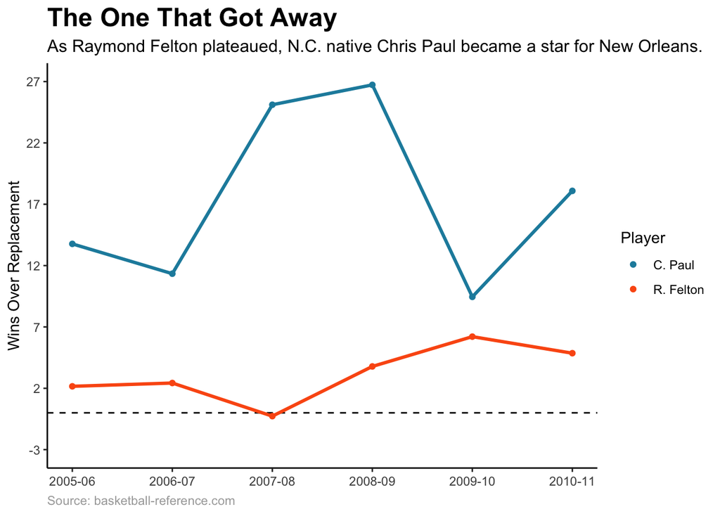

That wouldn’t be the only time New Orleans got the best of Charlotte in the draft. Let’s return to 2012 and take a closer look at one of the bigger what-ifs in Charlotte history.

The 2011-12 Bobcats made history as the worst NBA team of all time. They won just seven games in a lockout-shortened season and their winning .106 percentage was almost unfathomable. So the Hornets went into the 2012 draft lottery with the highest odds (25%) of winning the Anthony Davis sweepstakes.

The 2011-12 New Orleans Hornets were also bad, but they still won three times as many games as the Bobcats that season and held the fourth-best odds (13.7%) of winning the No. 1 pick. But because Charlotte appears to be perpetually cursed by the franchise they let walk in 2002, New Orleans stuck it to the Bobcats once more.

The Wins Over Replacement numbers for Davis and Kidd-Gilchrist can tell the rest of the story on their own.

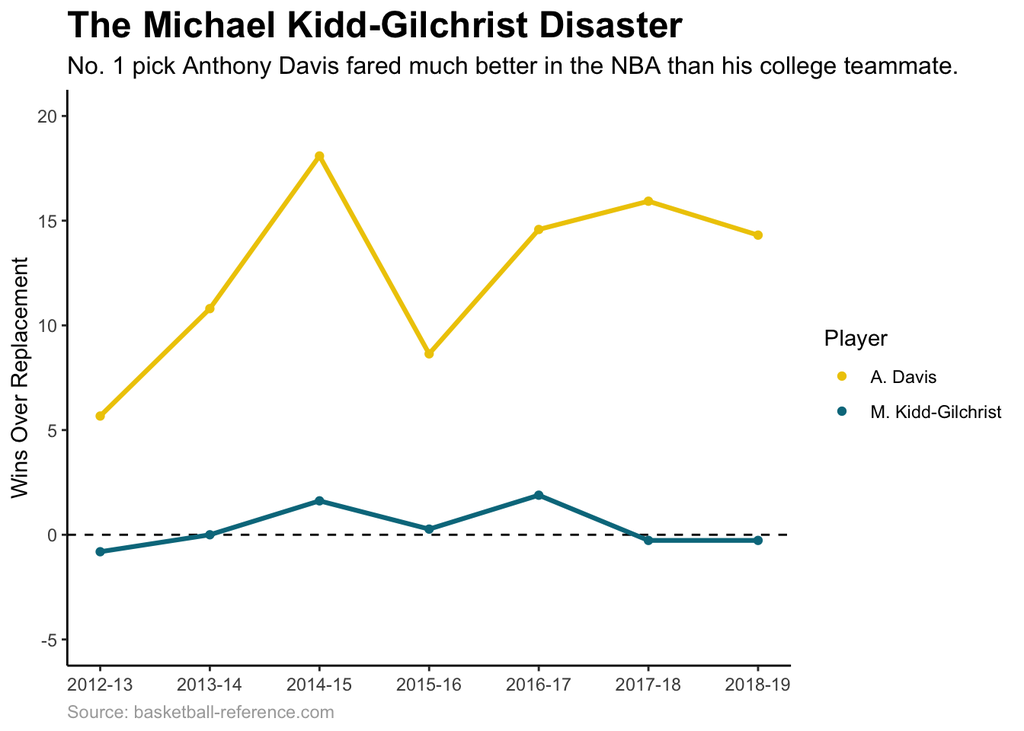

Anthony Davis appeared to be a sure thing, and other than a few injury-riddled seasons that has mostly been true over the course of his career. During his seven seasons in New Orleans, Davis contributed an estimated ~12.6 wins per season when compared to a replacement-level player.

Michael Kidd-Gilchrist’s numbers tell a different story. He also played seven seasons for the team that drafted him and made almost no impact during that time. His WORP numbers in Charlotte add up to 2.4 wins. Divide that across seven seasons and you get essentially zero added wins from season to season.

It’s even worse when you consider that sitting behing Kidd-Gilchrist were future Hall of Famers Damian Lillard and Draymond Green and All-Stars Bradley Beal and Andre Drummond. Charlotte’s lone No. 2 draft pick in its history was a bust through and through.

On June 22 the Hornets will have a chance to change that history when they make the second selection in the 2023 NBA Draft. Will they finally land the superstar they’ve been hoping for? Only time will tell. But there is one thing that should comfort the Charlotte front office – New Orleans isn’t picking ahead of them.

#### References

- Basketball Reference: [Charlotte Hornets](https://www.basketball-reference.com/teams/CHA/)
- RealGM: [Charlotte Hornets NBA Draft Lottery History](https://basketball.realgm.com/nba/teams/Charlotte-Hornets/3/Lottery-History)

#### A Must Watch

- Secret Base: [The People You’re Paying to Be in Shorts | Dorktown](https://www.youtube.com/watch?v=F3_whi6KuLo)